# Regression Analysis of Revenues Prediction Based on Employees Numbers

Group Project G3

2023-12-15

## Group Members

NUR SHAFIQAH BINTI MOHAMAD JOHARI:22119564

LAW JIA JIN:22071390

LIM CHENG YANG:22100811

LIM SZE SING:22109557

GAN JING WEN:22065433

## Introduction

This data science project aims to leverage data science techniques to explore and analyze the relationship between key factors affecting a company’s revenue and its potential for achieving positive revenue growth in the upcoming year, 2023.

The dataset at hand contains valuable information about 600 companies, including their revenue in 2022, employee count, past revenue growth, industry category, and location category.

The primary objectives of this project are:

1. To Explore the Relationship Between a Company’s Employee Count and Revenue in 2022:
- One of the key questions we aim to answer is whether there is a positive relationship between the number of employees in a company and its revenue in 2022. This analysis can provide insights into how a company’s workforce size correlates with its financial performance. Understanding this relationship can be instrumental for both businesses and investors in making informed decisions.
2. To Predict the Likelihood of Positive Revenue Growth in 2023
- The second objective of this project is to build a predictive model that can assess the likelihood of a company achieving positive revenue growth in the year 2023. This predictive capability can be invaluable for business planning, risk assessment, and investment strategies. By analyzing historical data, we can identify patterns and indicators that contribute to a company’s success in achieving positive revenue growth.

## Data Obtain

The dataset is obtained from the source of https://www.statista.com/companies/search?queries%5B%5D=ecommerce. Then, the dataset have been read by RStudio using read.csv. The basic information such as column names, total row numbers, total column numbers, data types and etc. are identified as followed by steps belows:

```r
# Set CRAN mirror
options(repos = c(CRAN = "https://cran.r-project.org"))

df <- read.csv("C:/Users/Gan Jing Wen/OneDrive - Lee Yin Group/ganPersonal/Master/WQD7004-PROGRAMMING FOR DATA SCIENCE/Group Project/Regression Analysis of Revenue Prediction Based on Employee Numbers.csv")


#check data information
head(df,5)
```

```
##                                  Name       Location      City           State
## 1           Ajso Global Ecommerce LLC  United States Anchorage          Alaska
## 2             Lcc Best Ecommerce Ltd. United Kingdom   Cardiff South Glamorgan
## 3              Astraza Ecommerce Ltd. United Kingdom     Hayes       Middlesex
## 4 Shanghai Kaijie Ecommerce Co., Ltd.          China  Shanghai        Shanghai
## 5       Grays Ecommerce Group Limited      Australia Moorebank New South Wales
##                                           Industry Revenue.in.2022
## 1                                          Tobacco     $450.9m USD
## 2 Electronic & Telecommunication Equipment & Parts     $418.3m USD
## 3 Electronic & Telecommunication Equipment & Parts     $404.3m USD
## 4              Retail Trade, Except Motor Vehicles     $374.2m USD
## 5                                       E-Commerce     $162.8m USD
##   Last.Revenue.Growth ISO.Code Employees IPO.Status Operating.Status
## 1               0.05%      USD       164    Private           Active
## 2              -2.72%      USD         6    Private           Active
## 3               0.03%      USD         6    Private           Active
## 4               0.41%      USD       825    Private           Active
## 5            1966.76%      USD       652    Private           Active
##   Founding.Year...Est.
## 1                  n/a
## 2                 2018
## 3                 2018
## 4                 2010
## 5                 1992
```

```r
print(paste("Number of records: ", nrow(df)))
```

```
## [1] "Number of records:  600"
```

```r
print(paste("Number of features: ", ncol(df)))
```

```
## [1] "Number of features:  12"
```

```r
colnames(df)
```

```
##  [1] "Name"                 "Location"             "City"
##  [4] "State"                "Industry"             "Revenue.in.2022"
##  [7] "Last.Revenue.Growth"  "ISO.Code"             "Employees"
## [10] "IPO.Status"           "Operating.Status"     "Founding.Year...Est."
```

```r
summary(df)
```

```
##      Name             Location             City              State
##  Length:600         Length:600         Length:600         Length:600
##  Class :character   Class :character   Class :character   Class :character
##  Mode  :character   Mode  :character   Mode  :character   Mode  :character
##    Industry         Revenue.in.2022    Last.Revenue.Growth   ISO.Code
##  Length:600         Length:600         Length:600          Length:600
##  Class :character   Class :character   Class :character    Class :character
##  Mode  :character   Mode  :character   Mode  :character    Mode  :character
##   Employees          IPO.Status        Operating.Status   Founding.Year...Est.
##  Length:600         Length:600         Length:600         Length:600
##  Class :character   Class :character   Class :character   Class :character
##  Mode  :character   Mode  :character   Mode  :character   Mode  :character
```

```r
str(df)
```

```
## 'data.frame':    600 obs. of  12 variables:
##  $ Name                : chr  "Ajso Global Ecommerce LLC" "Lcc Best Ecommerce Ltd." "Astraza Ecommerce Ltd." "Shanghai Kaijie Ecommerce Co., Ltd." ...
##  $ Location            : chr  "United States" "United Kingdom" "United Kingdom" "China" ...
##  $ City                : chr  "Anchorage" "Cardiff" "Hayes" "Shanghai" ...
##  $ State               : chr  "Alaska" "South Glamorgan" "Middlesex" "Shanghai" ...
##  $ Industry            : chr  "Tobacco" "Electronic & Telecommunication Equipment & Parts" "Electronic & Telecommunication Equipment & Parts" "Retail Trade, Except Motor Vehicles" ...
##  $ Revenue.in.2022     : chr  "$450.9m USD" "$418.3m USD" "$404.3m USD" "$374.2m USD" ...
##  $ Last.Revenue.Growth : chr  "0.05%" "-2.72%" "0.03%" "0.41%" ...
##  $ ISO.Code            : chr  "USD" "USD" "USD" "USD" ...
##  $ Employees           : chr  "164" "6" "6" "825" ...
##  $ IPO.Status          : chr  "Private" "Private" "Private" "Private" ...
##  $ Operating.Status    : chr  "Active" "Active" "Active" "Active" ...
##  $ Founding.Year...Est.: chr  "n/a" "2018" "2018" "2010" ...
```

## Data Cleaning

In Data Cleaning, duplicate rows and missing data are identified. The unnecessary column will be removed in order to reduce noise from the dataset. The missing data are converted from “n/a” to standard representation of missing value in R programming which is “NA”. Then, the categorical data are separated into few parent categories in order to give clearer picture and provide informative insights.

```r
#Remove unnecessary column
df1 <- df[,c("Location", "Industry", "Revenue.in.2022","Employees","Last.Revenue.Growth","Founding.Year...Est.")]
head(df1,5)
```

```
##         Location                                         Industry
## 1  United States                                          Tobacco
## 2 United Kingdom Electronic & Telecommunication Equipment & Parts
## 3 United Kingdom Electronic & Telecommunication Equipment & Parts
## 4          China              Retail Trade, Except Motor Vehicles
## 5      Australia                                       E-Commerce
##   Revenue.in.2022 Employees Last.Revenue.Growth Founding.Year...Est.
## 1     $450.9m USD       164               0.05%                  n/a
## 2     $418.3m USD         6              -2.72%                 2018
## 3     $404.3m USD         6               0.03%                 2018
## 4     $374.2m USD       825               0.41%                 2010
## 5     $162.8m USD       652            1966.76%                 1992
```

```r
df1[df1 == "n/a"] <- NA       #change n/a to NA (standard representation of missing value)
colSums(is.na(df1))
```

```
##             Location             Industry      Revenue.in.2022
##                    0                   51                    0
##            Employees  Last.Revenue.Growth Founding.Year...Est.
##                    1                    1                  256
```

```r
#Cleaning for categorical data
#for industry column
library(dplyr)
```

```r
df1$Industry.Category <- "Other"  # Default

# Consolidate based on keywords
industry_hierarchy <- list(
  "IT & Computer Services" = c("Computer Programming", "Computer Programming, Consultancy", "Other IT & Computer Services"),
  "Telecommunications" = c("Telecommunications", "Other Telecommunications"),
  "Finance & Insurance" = c("Finance-Related Services, Except Insurance & Pension Funding", "Finance & Insurance", "Finance & Insurance-Related Activities", "Reinsurance", "Trusts, Funds & Similar Financial Entities","Insurance & Pension-Related Services"),
  "Retail Trade" = c("Wholesale Trade, Except Motor Vehicles","Dairy Products","Non-Specialized Wholesale Trade","Retail Trade, Except Motor Vehicles", "Retail Sales via Stalls & Markets", "Other Non-Specialized Stores", "Other Specialized Wholesale Activities","Wholesale & Retail Trade, Including Motor Vehicle Repairs" ),
  "Electrical components" = c("Electronic Components & Boards","Electronic & Telecommunication Equipment & Parts"),
  "E-commerce" = "E-Commerce",
  "Media" = c("Information & Communication","Clothing, Footwear & Leather Articles","Electrical Household Appliances, Furniture, Lighting Equipment & Other Articles","Advertising","Radio Broadcasting","Books, Newspapers & Stationery"),
  "Texiles" = c("Textiles, Clothing & Footwear","Textiles","Other Textiles"),
  "Construction" = c("Real Estate","Construction") ,
  "F&B" = c("Food, Beverages & Tobacco Wholesales","Food","Soft Drinks & Water","Malt Liquors & Malt","Other Food Services","Tobacco"),
  "Transportation & Storage" = c("Postal Services","Transportation & Storage", "Other Transportation Support Activities", "Warehousing & Storage","Courier Services"),
  "Administration" = c("Computer Consultancy & Facilities Management","Administrative & Supportive Services","Management Consultancy"),
  "Professional" = c("Electrical Household Appliances, Furniture, Lighting Equipment & Other Articles","Travel Agencies","Professional, Scientific & Technical Services","Education","Research & Experimental Development on Natural Sciences & Engineering","Pharmaceutical or Medical Goods, Cosmetic & Toilet Articles") ,
  "Other" = "Other"  # Default category for unmatched values
)

# Loop through hierarchy and apply consolidation
for (parent_category in names(industry_hierarchy)) {
  subcategories <- industry_hierarchy[[parent_category]]
  df1$Industry.Category[grepl(paste(subcategories, collapse = "|"), df1$Industry, ignore.case = TRUE)] <- parent_category
}
industry_counts <- table(df1$Industry.Category)
industry_counts
```

```
##
##           Administration             Construction               E-commerce
##                       59                        7                       64
##    Electrical components                      F&B      Finance & Insurance
##                        3                       11                       13
##   IT & Computer Services                    Media                    Other
##                       70                       16                      164
##             Professional             Retail Trade       Telecommunications
##                        7                      154                       16
##                  Texiles Transportation & Storage
##                        6                       10
```

```r
#For location column
table(df1$Location)
```

```
##
##            Australia              Austria              Bahrain
##                    5                    1                    1
##              Belgium               Brazil               Canada
##                    1                    1                    7
##                China              Denmark                Egypt
##                   98                    1                    1
##              Finland               France              Germany
##                    2                    1                   80
##  Hong Kong SAR China                India            Indonesia
##                    7                  228                    4
##              Ireland               Israel                Italy
##                    2                    1                    8
##               Jordan              Lebanon                Libya
##                    3                    1                    1
##             Malaysia            Mauritius              Morocco
##                    8                    1                    2
##          Netherlands          New Zealand              Nigeria
##                    2                    2                    1
##               Norway          Philippines               Poland
##                    1                    1                    2
##                Qatar               Russia         Saudi Arabia
##                    2                    1                    2
##            Singapore         South Africa          South Korea
##                    3                    4                    1
##                Spain               Sweden               Taiwan
##                    5                    1                    1
##             Tanzania             Thailand United Arab Emirates
##                    1                    4                    3
##       United Kingdom        United States           Uzbekistan
##                   43                   46                    1
##              Vietnam
##                    8
```

```r
df1$location.Category <- "Other"  # Default

location_hierarchy <- list(
  "Australia & New Zealand" = c("Australia", "New Zealand"),
  "Europe" = c("Austria", "Belgium", "Denmark", "Finland", "France", "Germany", "Ireland","United Kingdom",
               "Italy", "Netherlands", "Norway", "Poland", "Spain", "Sweden","Russia") ,
  "Middle East" = c("Bahrain", "Jordan", "Lebanon", "Qatar", "Saudi Arabia", "United Arab Emirates"),
  "North & South America" = c("Brazil", "Canada", "United States"),
  "Asia-Pacific" =c("China", "Hong Kong SAR China", "India", "Indonesia", "Israel", "Japan",
              "Malaysia", "Philippines", "Singapore", "South Korea", "Taiwan", "Thailand",
              "Vietnam","Uzbekistan"),
  "Africa" = c("Egypt", "Libya", "Mauritius", "Morocco", "Nigeria", "South Africa", "Tanzania"),
  "Other" = "Other"
)

# Loop through hierarchy and apply consolidation
for (country in names(location_hierarchy)) {
  subcategories <- location_hierarchy[[country]]
  df1$Location.Category[grepl(paste(subcategories, collapse = "|"), df1$Location, ignore.case = TRUE)] <- country
}
location_counts <- table(df1$Location.Category)
location_counts
```

```
##
##                  Africa            Asia-Pacific Australia & New Zealand
##                      11                     365                       7
##                  Europe             Middle East   North & South America
##                     151                      12                      54
```

After cleaning the categorical data, the numeric data will be cleaned by checking the impact of the variable itself using correlation matrix or based on the percentage of missing value as compared to overall dataset.

```r
#Select only the numeric column for cleaning
Maindf <- df1[,c("Revenue.in.2022","Employees","Last.Revenue.Growth","Founding.Year...Est.")]

#Re-check the data information
print(paste("Number of records: ", nrow(Maindf)))
```

```
## [1] "Number of records:  600"
```

```r
print(paste("Number of features: ", ncol(Maindf)))
```

```
## [1] "Number of features:  4"
```

```r
colnames(Maindf)
```

```
## [1] "Revenue.in.2022"      "Employees"            "Last.Revenue.Growth"
## [4] "Founding.Year...Est."
```

```r
summary(Maindf)
```

```
##  Revenue.in.2022     Employees         Last.Revenue.Growth Founding.Year...Est.
##  Length:600         Length:600         Length:600          Length:600
##  Class :character   Class :character   Class :character    Class :character
##  Mode  :character   Mode  :character   Mode  :character    Mode  :character
```

```r
str(Maindf)
```

```
## 'data.frame':    600 obs. of  4 variables:
##  $ Revenue.in.2022     : chr  "$450.9m USD" "$418.3m USD" "$404.3m USD" "$374.2m USD" ...
##  $ Employees           : chr  "164" "6" "6" "825" ...
##  $ Last.Revenue.Growth : chr  "0.05%" "-2.72%" "0.03%" "0.41%" ...
##  $ Founding.Year...Est.: chr  NA "2018" "2018" "2010" ...
```

```r
# Count the number of duplicate rows
num_duplicates <- sum(duplicated(df))
print(num_duplicates)
```

```
## [1] 0
```

```r
#check missing data
any_missing <- any(Maindf == "n/a", na.rm = TRUE)
Maindf[Maindf == "n/a"] <- NA       #change n/a to NA (standard representation of missing value)
colSums(is.na(Maindf))              #count number of NA per column
```

```
##      Revenue.in.2022            Employees  Last.Revenue.Growth
##                    0                    1                    1
## Founding.Year...Est.
##                  256
```

```r
colSums(!is.na(Maindf))             #check number of filled values per column
```

```
##      Revenue.in.2022            Employees  Last.Revenue.Growth
##                  600                  599                  599
## Founding.Year...Est.
##                  344
```

```r
is.null(Maindf)                    #check nothingness
```

```
## [1] FALSE
```

Since there are only 1 rows of Employees and 1 rows of Last.Revenue.Growth are having missing values, which is less than 10% of the overall dataset. We decided to directly remove the 2 rows mentioned.

```r
#remove missing column of employees and revenue
clean_Employees <- Maindf[complete.cases(Maindf$Employees), ]
print(sum(is.na(clean_Employees$Employees)))
```

```
## [1] 0
```

```r
print(sum(!is.na(clean_Employees$Employees)))
```

```
## [1] 599
```

```r
clean_Revenue <- clean_Employees[complete.cases(clean_Employees$Last.Revenue.Growth), ]
clean_Maindf<- clean_Revenue
print(sum(is.na(clean_Maindf$Last.Revenue.Growth)))
```

```
## [1] 0
```

```r
print(sum(!is.na(clean_Maindf$Last.Revenue.Growth)))
```

```
## [1] 598
```

```r
summary(clean_Maindf)
```

```
##  Revenue.in.2022     Employees         Last.Revenue.Growth Founding.Year...Est.
##  Length:598         Length:598         Length:598          Length:598
##  Class :character   Class :character   Class :character    Class :character
##  Mode  :character   Mode  :character   Mode  :character    Mode  :character
```

```r
colSums(is.na(clean_Maindf))
```

```
##      Revenue.in.2022            Employees  Last.Revenue.Growth
##                    0                    0                    0
## Founding.Year...Est.
##                  256
```

```r
colSums(!is.na(clean_Maindf))
```

```
##      Revenue.in.2022            Employees  Last.Revenue.Growth
##                  598                  598                  598
## Founding.Year...Est.
##                  342
```

There are 256/600 missing values for Founding.Year…Est. Hence, the data frame is converted from character to numeric in order to perform the impact assessment using correlation matrix. Meanwhile, all “NA” rows under Founding.Year…Est. will be temporary eliminated during correlation matrix calculation.

```r
#Before calculation, need to convert all from character to numeric
unique(clean_Maindf$Employees)  #to check why unable to direct convert
```

```
##   [1] "164"   "6"     "825"   "652"   "295"   "296"   "290"   "376"   "292"
##  [10] "291"   "293"   "299"   "289"   "294"   "391"   "298"   "297"   "22"
##  [19] "196"   "135"   "369"   "467"   "46"    "891"   "261"   "924"   "16"
##  [28] "97"    "112"   "94"    "313"   "184"   "110"   "98"    "27"    "56"
##  [37] "14"    "29"    "99"    "510"   "60"    "109"   "23"    "89"    "26"
##  [46] "36"    "1"     "964"   "146"   "88"    "63"    "31"    "21"    "191"
##  [55] "337"   "301"   "20"    "19"    "13"    "12"    "310"   "216"   "58"
##  [64] "148"   "86"    "70"    "5"     "50"    "49"    "134"   "118"   "121"
##  [73] "136"   "87"    "199"   "214"   "41"    "47"    "55"    "40"    "193"
##  [82] "44"    "24"    "11"    "236"   "17"    "157"   "3"     "96"    "176"
##  [91] "38"    "188"   "79"    "69"    "66"    "67"    "42"    "30"    "25"
## [100] "65"    "150"   "18"    "151"   "2"     "77"    "53"    "155"   "4"
## [109] "28"    "10"    "9"     "271"   "75"    "37"    "34"    "33"    "7"
## [118] "35"    "113"   "102"   "82"    "32"    "81"    "115"   "103"   "78"
## [127] "51"    "95"    "83"    "54"    "325"   "15"    "39"    "93"    "92"
## [136] "541"   "48"    "8"     "43"    "64"    "1,311" "59"    "57"    "71"
```

```r
sapply(clean_Maindf, class)
```

```
##      Revenue.in.2022            Employees  Last.Revenue.Growth
##          "character"          "character"          "character"
## Founding.Year...Est.
##          "character"
```

```r
str(clean_Maindf)
```

```
## 'data.frame':    598 obs. of  4 variables:
##  $ Revenue.in.2022     : chr  "$450.9m USD" "$418.3m USD" "$404.3m USD" "$374.2m USD" ...
##  $ Employees           : chr  "164" "6" "6" "825" ...
##  $ Last.Revenue.Growth : chr  "0.05%" "-2.72%" "0.03%" "0.41%" ...
##  $ Founding.Year...Est.: chr  NA "2018" "2018" "2010" ...
```

```r
# Revenue in 2022: Remove "$" and "m USD" and convert to numeric
clean_Maindf$Revenue.in.2022 <- as.numeric(substr(clean_Maindf$Revenue.in.2022, 2, nchar(clean_Maindf$Revenue.in.2022) - 6))
# Last Revenue Growth: Remove "%"
clean_Maindf$Last.Revenue.Growth <- as.numeric(substr(clean_Maindf$Last.Revenue.Growth, 1, nchar(clean_Maindf$Last.Revenue.Growth) - 1))
# Other: normal convert
clean_Maindf$Founding.Year...Est. <- as.numeric(clean_Maindf$Founding.Year...Est.)
clean_Maindf$Employees <- as.numeric(gsub(",", "", clean_Maindf$Employees))
clean_Maindf$Employees <- as.numeric(clean_Maindf$Employees)
colSums(is.na(clean_Maindf))
```

```
##      Revenue.in.2022            Employees  Last.Revenue.Growth
##                    0                    0                    0
## Founding.Year...Est.
##                  256
```

```r
colSums(!is.na(clean_Maindf))
```

```
##      Revenue.in.2022            Employees  Last.Revenue.Growth
##                  598                  598                  598
## Founding.Year...Est.
##                  342
```

```r
#For Funding Years, to check whether the variable is impact on revenue, correlation matrix is calculated after eliminate all NA column.
#Clean NA rows for Founding year
clean_Founding <- clean_Maindf[complete.cases(clean_Maindf$Founding.Year...Est.), ]
print(sum(is.na(clean_Founding$Founding.Year...Est.)))
```

```
## [1] 0
```

```r
print(sum(!is.na(clean_Founding$Founding.Year...Est.)))
```

```
## [1] 342
```

```r
colSums(is.na(clean_Founding))
```

```
##      Revenue.in.2022            Employees  Last.Revenue.Growth
##                    0                    0                    0
## Founding.Year...Est.
##                    0
```

```r
colSums(!is.na(clean_Founding))
```

```
##      Revenue.in.2022            Employees  Last.Revenue.Growth
##                  342                  342                  342
## Founding.Year...Est.
##                  342
```

```r
head(clean_Founding,5)
```

```
##   Revenue.in.2022 Employees Last.Revenue.Growth Founding.Year...Est.
## 2             418         6               -2.72                 2018
## 3             404         6                0.03                 2018
## 4             374       825                0.41                 2010
## 5             162       652             1966.76                 1992
## 6             150       295              -10.61                 2019
```

```r
# Correlation Matrix Calculation
cor_matrix <- cor(clean_Founding)
print(cor_matrix)
```

```
##                      Revenue.in.2022   Employees Last.Revenue.Growth
## Revenue.in.2022            1.0000000  0.41195643           0.1636159
## Employees                  0.4119564  1.00000000           0.1997368
## Last.Revenue.Growth        0.1636159  0.19973677           1.0000000
## Founding.Year...Est.       0.0363452 -0.07226679          -0.1898559
##                      Founding.Year...Est.
## Revenue.in.2022                0.03634520
## Employees                     -0.07226679
## Last.Revenue.Growth           -0.18985586
## Founding.Year...Est.           1.00000000
```

Based on Correlation Matrix, Founding year have no correlation with any of the other value. Hence, by considering it consists of high number of missing value, the entire column is decided to be removed and new data frame is created.

```r
#New data frame after remove unnecessary columns.
Final_df <- clean_Maindf[,c("Revenue.in.2022","Employees","Last.Revenue.Growth")]
head(Final_df,5)
```

```
##   Revenue.in.2022 Employees Last.Revenue.Growth
## 1             450       164                0.05
## 2             418         6               -2.72
## 3             404         6                0.03
## 4             374       825                0.41
## 5             162       652             1966.76
```

```r
sapply(Final_df, class)
```

```
##     Revenue.in.2022           Employees Last.Revenue.Growth
##           "numeric"           "numeric"           "numeric"
```

```r
summary(Final_df)
```

```
##  Revenue.in.2022    Employees       Last.Revenue.Growth
##  Min.   :  2.00   Min.   :   1.00   Min.   : -50.280
##  1st Qu.:  3.00   1st Qu.:  17.00   1st Qu.:  -4.407
##  Median :  4.00   Median :  26.00   Median :   0.785
##  Mean   : 15.38   Mean   :  64.91   Mean   :   4.736
##  3rd Qu.: 11.00   3rd Qu.:  58.00   3rd Qu.:   6.570
##  Max.   :450.00   Max.   :1311.00   Max.   :1966.760
```

```r
colSums(is.na(Final_df))
```

```
##     Revenue.in.2022           Employees Last.Revenue.Growth
##                   0                   0                   0
```

```r
colSums(!is.na(Final_df))
```

```
##     Revenue.in.2022           Employees Last.Revenue.Growth
##                 598                 598                 598
```

Effectiveness of Data Cleaning will be check using Histogram for skewness and BOX-plot for outlier. For skewness, due to both columns of Employees and Revenue.in.2022 shows highly positive skewness towards right side, the log-transformation method have been used to transform the data towards more symmetric result. By comparing the result of original data frame and log-transformed data frame,the similar results shows least impact of log-transform to correlation matrix.Hence, the transformation is acceptable and will not impact on prediction results.

```r
# Check Skeness
#install.packages("psych")
#library(psych)
```

```r
# Check data types
class(Final_df$Employees)
```

```
## [1] "numeric"
```

```r
# Convert to numeric
#your_data$variable <- as.numeric(your_data$variable)
```

```r
# Install and load the moments package if not already installed
if (!requireNamespace("moments", quietly = TRUE)) {
  install.packages("moments")
}
library(moments)

# Raw data skewness
skew_bf_Emp <- skewness(Final_df$Employees)
skew_bf_Rev <- skewness(Final_df$Revenue.in.2022)
print(paste("Original Skewness of Employees:",skew_bf_Emp))
```

```
## [1] "Original Skewness of Employees: 5.24076350661127"
```

```r
print(paste("Original Skewness of Revenue in 2022:",skew_bf_Rev))
```

```
## [1] "Original Skewness of Revenue in 2022: 6.79583855575997"
```

```r
# Log transformation
Final_df$Employees_log <- log(Final_df$Employees)
Final_df$Revenue.in.2022_log <- log(Final_df$Revenue.in.2022)

# Check the skewness after transformation
skew_af_Emp <- skewness(Final_df$Employees_log)
skew_af_Rev <- skewness(Final_df$Revenue.in.2022_log)
print(paste("Log-Transformed Skewness of Employees:",skew_af_Emp))
```

```
## [1] "Log-Transformed Skewness of Employees: 0.339652217942924"
```

```r
print(paste("Log-Transformed Skewness of Revenue in 2022:",skew_af_Rev))
```

```
## [1] "Log-Transformed Skewness of Revenue in 2022: 1.45843768575374"
```

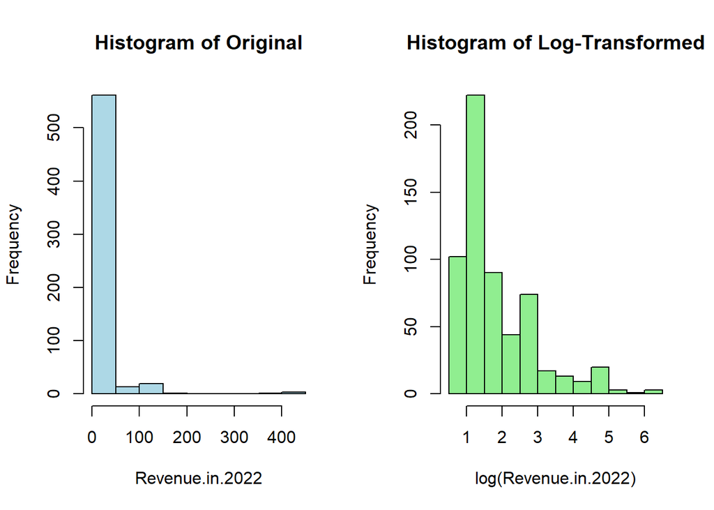

```r
# Create histograms for both the original and log-transformed variables
par(mfrow=c(1,2))  # Set up a 1x2 grid for side-by-side plots

# Original variable
hist(Final_df$Revenue.in.2022,
     main = "Histogram of Original",
     xlab = "Revenue.in.2022",
     col = "lightblue",
     border = "black")

# Transformed variable
hist(log(Final_df$Revenue.in.2022),
     main = "Histogram of Log-Transformed",
     xlab = "log(Revenue.in.2022)",
     col = "lightgreen",
     border = "black")
```

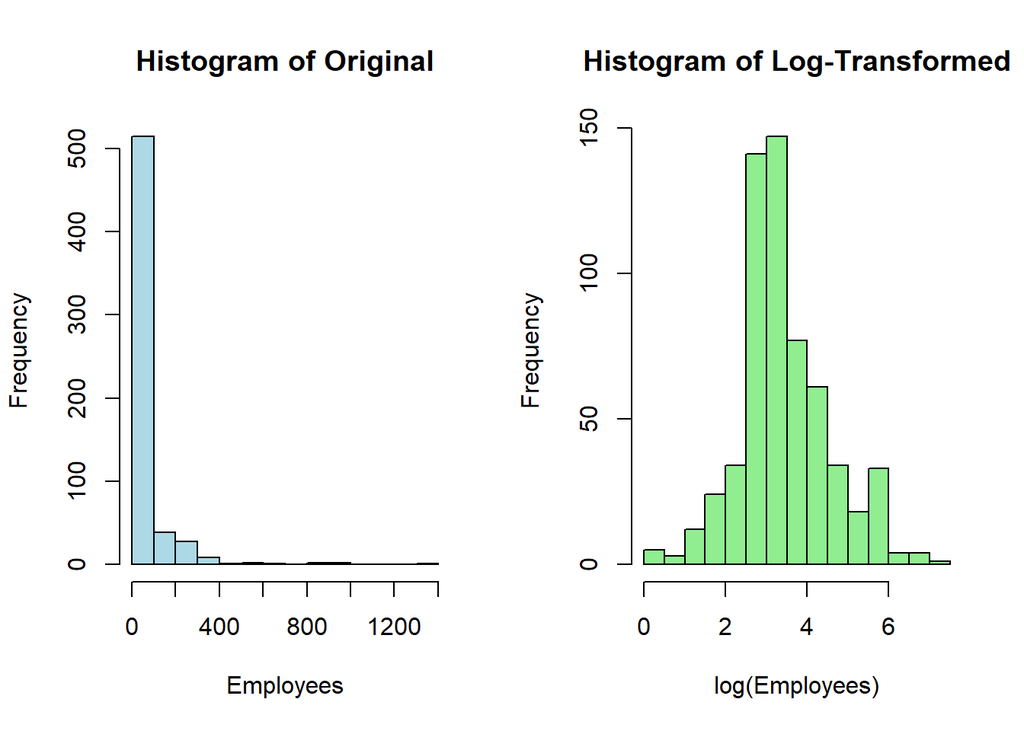

```r
# Original variable
hist(Final_df$Employees,
     main = "Histogram of Original",
     xlab = "Employees",
     col = "lightblue",
     border = "black")

# Transformed variable
hist(log(Final_df$Employees),
     main = "Histogram of Log-Transformed",
     xlab = "log(Employees)",
     col = "lightgreen",
     border = "black")
```

```r
# Correlation Matrix Calculation
cor_matrix <- cor(Final_df)
print(cor_matrix)
```

```
##                     Revenue.in.2022 Employees Last.Revenue.Growth Employees_log
## Revenue.in.2022           1.0000000 0.4200475           0.1490019     0.3410082
## Employees                 0.4200475 1.0000000           0.2009087     0.7411684
## Last.Revenue.Growth       0.1490019 0.2009087           1.0000000     0.1095717
## Employees_log             0.3410082 0.7411684           0.1095717     1.0000000
## Revenue.in.2022_log       0.7358805 0.5179241           0.1267887     0.5262732
##                     Revenue.in.2022_log
## Revenue.in.2022               0.7358805
## Employees                     0.5179241
## Last.Revenue.Growth           0.1267887
## Employees_log                 0.5262732
## Revenue.in.2022_log           1.0000000
```

```r
#The results shows least impact of log-transform to correlation matrix.The transformation is acceptable.
```

Next, outlier have been verified using BOX-plot for log-values. By using the range of 3.0 (range: 1.5-3.0 for normal to moderately skeness data), the results shows there are outliers existing in the data frame for column Last.Revenue.Growth. Hence, the outliers are removed and new BOX-plot after outlier removal is plotted.

```r
head (Final_df,5)
```

```
##   Revenue.in.2022 Employees Last.Revenue.Growth Employees_log
## 1             450       164                0.05      5.099866
## 2             418         6               -2.72      1.791759
## 3             404         6                0.03      1.791759
## 4             374       825                0.41      6.715383
## 5             162       652             1966.76      6.480045
##   Revenue.in.2022_log
## 1            6.109248
## 2            6.035481
## 3            6.001415
## 4            5.924256
## 5            5.087596
```

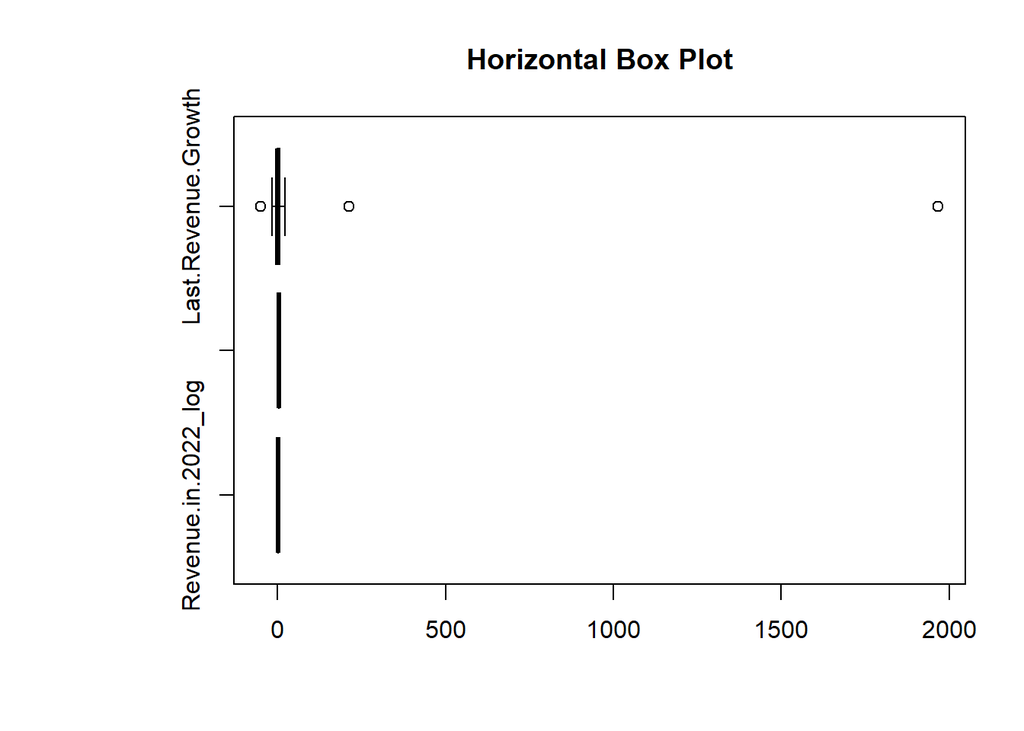

```r
#BOX plot for checking outliers
par(mar = c(5, 8, 4, 2))
Final_df_log1 <- Final_df[, c("Revenue.in.2022_log", "Employees_log", "Last.Revenue.Growth")]
boxplot(Final_df_log1, col = c("lightblue", "lightgreen", "lightpink"), horizontal = TRUE, main = "Horizontal Box Plot", range = 3.0)
```

```r
#Remove outliers
outliers_col <- boxplot.stats(Final_df_log1$Last.Revenue.Growth)$out
outliers <- unique(c(outliers_col))
outliers
```

```
## [1] 1966.76  213.08  -50.28
```

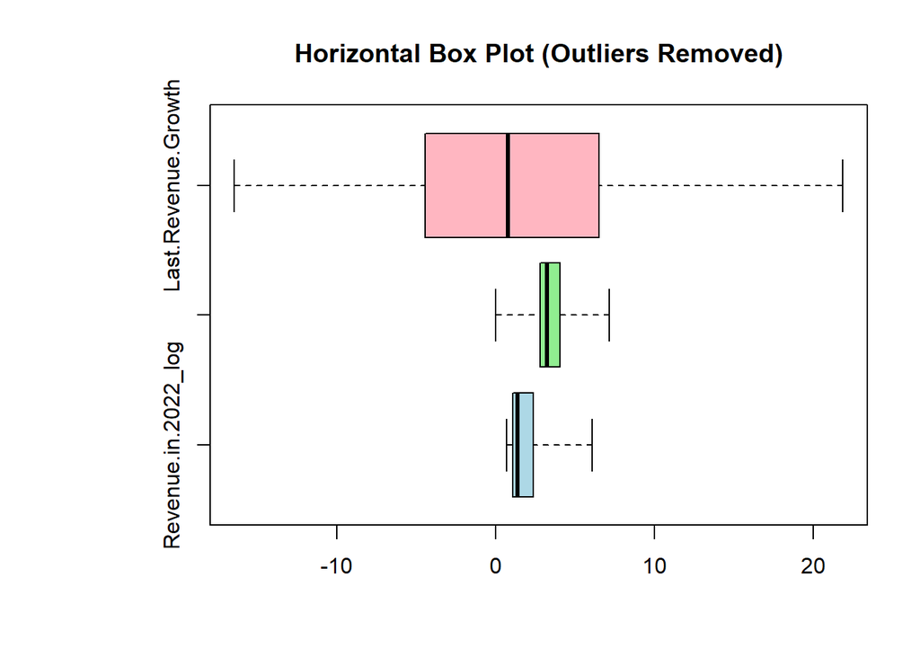

```r
Final_df_log <- Final_df_log1[!Final_df_log1$Last.Revenue.Growth %in% outliers, ]

#BOX plot after remove outliers
boxplot(Final_df_log, col = c("lightblue", "lightgreen", "lightpink"), horizontal = TRUE, main = "Horizontal Box Plot (Outliers Removed)", range = 3.0)
```

```r
head(Final_df,5)
```

```
##   Revenue.in.2022 Employees Last.Revenue.Growth Employees_log
## 1             450       164                0.05      5.099866
## 2             418         6               -2.72      1.791759
## 3             404         6                0.03      1.791759
## 4             374       825                0.41      6.715383
## 5             162       652             1966.76      6.480045
##   Revenue.in.2022_log
## 1            6.109248
## 2            6.035481
## 3            6.001415
## 4            5.924256
## 5            5.087596
```

```r
head(Final_df_log,5)
```

```
##   Revenue.in.2022_log Employees_log Last.Revenue.Growth
## 1            6.109248      5.099866                0.05
## 2            6.035481      1.791759               -2.72
## 3            6.001415      1.791759                0.03
## 4            5.924256      6.715383                0.41
## 6            5.010635      5.686975              -10.61
```

After cleaning all the numeric data, the dataset is combine again with the cleaned categorical data.

```r
Final_df_log <- cbind(Final_df_log, Industry.Category = df1$Industry.Category[match(rownames(Final_df_log), rownames(df1))])
head(Final_df_log,5)
```

```
##   Revenue.in.2022_log Employees_log Last.Revenue.Growth     Industry.Category
## 1            6.109248      5.099866                0.05                   F&B
## 2            6.035481      1.791759               -2.72 Electrical components
## 3            6.001415      1.791759                0.03 Electrical components
## 4            5.924256      6.715383                0.41          Retail Trade
## 6            5.010635      5.686975              -10.61                 Other
```

```r
Final_df_log <- cbind(Final_df_log, Location.Category = df1$Location.Category[match(rownames(Final_df_log), rownames(df1))])
head(Final_df_log,5)
```

```
##   Revenue.in.2022_log Employees_log Last.Revenue.Growth     Industry.Category
## 1            6.109248      5.099866                0.05                   F&B
## 2            6.035481      1.791759               -2.72 Electrical components
## 3            6.001415      1.791759                0.03 Electrical components
## 4            5.924256      6.715383                0.41          Retail Trade
## 6            5.010635      5.686975              -10.61                 Other
##       Location.Category
## 1 North & South America
## 2                Europe
## 3                Europe
## 4          Asia-Pacific
## 6                Europe
```

The data frame : Final_df_log, will be used for next process onwards.

## Exploratory Data Analysis (EDA)

Extrapolatory data analysis (EDA) is defined as initial analysis and findings done with data sets, usually early on in the analytical process. It enables us to visualize data to identify data characteristics in the form of numerical and graphical summaries. In general, we use EDA to understand and summarize the contents of data for the purpose of investigating a specific question or preparing for a more advanced modeling.

### Understanding Dataset

First we will get the summary statistic to get an overview of the central tendencies.

```r
# Check column names
colnames(Final_df_log)
```

```
## [1] "Revenue.in.2022_log" "Employees_log"       "Last.Revenue.Growth"
## [4] "Industry.Category"   "Location.Category"
```

```r
# summarization of all columns
summary(Final_df_log)
```

```
##  Revenue.in.2022_log Employees_log   Last.Revenue.Growth Industry.Category
##  Min.   :0.6931      Min.   :0.000   Min.   :-16.440     Length:595
##  1st Qu.:1.0986      1st Qu.:2.833   1st Qu.: -4.405     Class :character
##  Median :1.3863      Median :3.258   Median :  0.780     Mode  :character
##  Mean   :1.7724      Mean   :3.448   Mean   :  1.181
##  3rd Qu.:2.3979      3rd Qu.:4.052   3rd Qu.:  6.545
##  Max.   :6.1092      Max.   :7.179   Max.   : 21.880
##  Location.Category
##  Length:595
##  Class :character
##  Mode  :character
##
##
##
```

As we can see here in our dataset, `Industry` and `Location` data are attributed as data with values within **categorical** variables. Meanwhile, `Revenue.in.2022_log`, `Employees_log`, `Last.Revenue.Growth` are attributed as data with values within **numeric variables**. Based on this information, it is evident that all our data can be categorized as structured data, as both the **categorical** and **numerical** data belong to this classification.

### Understanding Numeric Variables

Let’s focus on **numeric variables** exploratory first in this section.

1. Box Plot

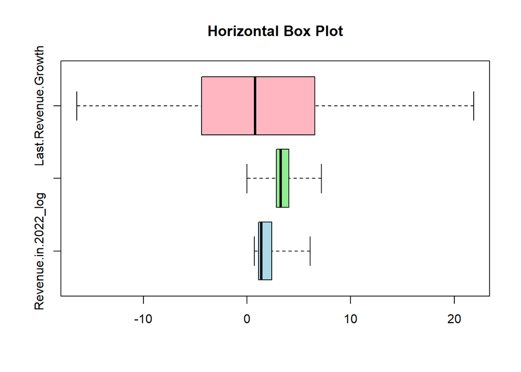

```r
#download necessary libraries
library(ggplot2)
library(reshape2)
library(gridExtra)
library(dplyr)

# Ensure only numeric columns
numeric_cols <- Final_df_log[, sapply(Final_df_log, is.numeric)]

#BOX plot
boxplot(numeric_cols, col = c("lightblue", "lightgreen", "lightpink"), horizontal = TRUE, main = "Horizontal Box Plot", range = 3.0)
```

2. Histogram

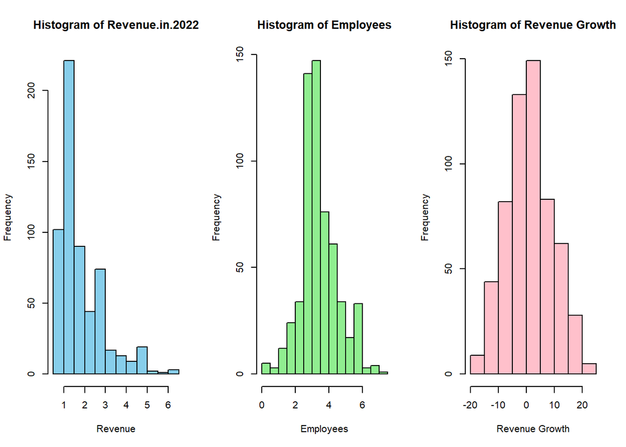

```r
par(mfrow = c(1, 3))

# Create histogram for Revenue.in.2022_log
hist(Final_df_log$Revenue.in.2022_log,
     main = "Histogram of Revenue.in.2022",
     xlab = "Revenue",
     col = "skyblue")

# Create histogram for Employees_log
hist(Final_df_log$Employees_log,
     main = "Histogram of Employees",
     xlab = "Employees",
     col = "lightgreen")

# Create histogram for Employees_log with a specific color
hist(Final_df_log$Last.Revenue.Growth,
     main = "Histogram of Revenue Growth",
     xlab = "Revenue Growth",
     col = "pink")
```

If we try to describe the dependent variable here, `Revenue.in.2022` has less variance compared to `Last.Revenue.Growth`, however the central tendency `Revenue.in.2022` is more skewed compared to `Last.Revenue.Growth`.

### Understanding Categorical Variables

Now let’s explore the **categorical** variables

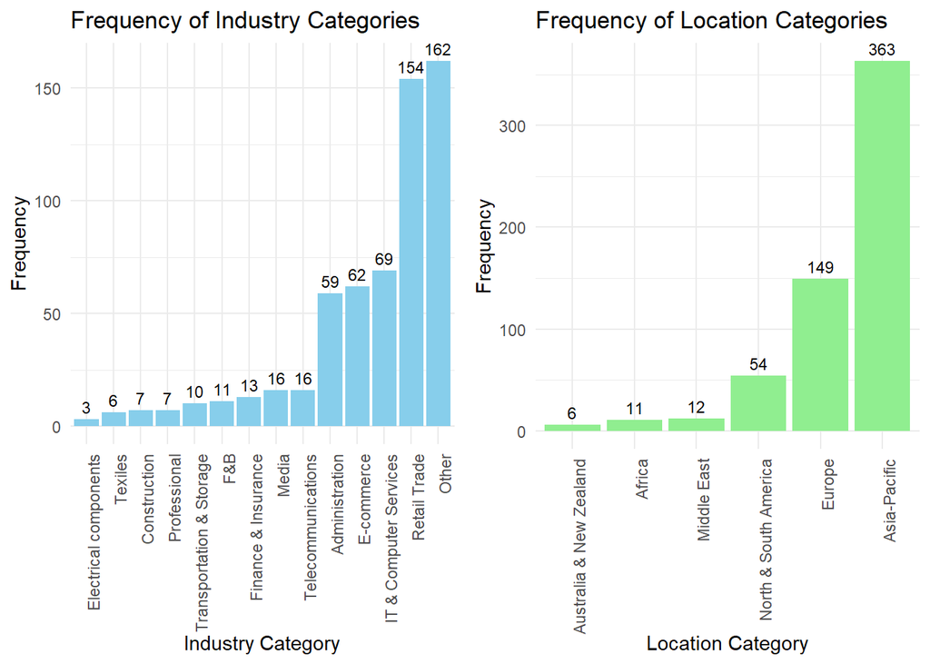

```r
# Create a table for counts of Industry.Category
industry_counts <- table(Final_df_log$Industry.Category)

# Create a table for counts of Location.Category
location_counts <- table(Final_df_log$Location.Category)

# Create data frames for ggplot
industry_data <- data.frame(Var1 = names(industry_counts), Freq = as.vector(industry_counts))
location_data <- data.frame(Var1 = names(location_counts), Freq = as.vector(location_counts))

# Plotting individual bar charts for Industry and Location categories using ggplot2
p1 <- ggplot(industry_data, aes(x = reorder(Var1, Freq), y = Freq)) +
  geom_bar(stat = "identity", fill = "skyblue") +
  geom_text(aes(label = Freq), vjust = -0.5, size = 3, color = "black") +
  labs(title = "Frequency of Industry Categories", x = "Industry Category", y = "Frequency") +
  theme_minimal() +
  theme(axis.text.x = element_text(angle = 90, hjust = 1))

p2 <- ggplot(location_data, aes(x = reorder(Var1, Freq), y = Freq)) +
  geom_bar(stat = "identity", fill = "lightgreen") +
  geom_text(aes(label = Freq), vjust = -0.5, size = 3, color = "black") +
  labs(title = "Frequency of Location Categories", x = "Location Category", y = "Frequency") +
  theme_minimal() +
  theme(axis.text.x = element_text(angle = 90, hjust = 1))

# Displaying graphs side by side using grid.arrange()
grid.arrange(p1, p2, ncol = 2)
```

From this, we can conclude that our dataset consist of multiple industries mainly from Asia-Pacific.

Now that we have understand all the columns and types of data that we have, let’s start to do necessary analysis to help structure our model.

### Analyzing Data

Since we will focus on Revenues prediction in our project, let’s see if we can identify the dependent variable as `Revenue.in.2022_log` or `Last.Revenue.Growth` by the end of the process. However, we will need to first break down the process to Numerical vs. Numerical and Categorical vs. Numerical Correlation since our data is structured data.

#### Numerical vs. Numerical Correlation

For the independent variable, since we only have `Employees_log` as our option under numerical value, let’s have a check on the correlation of this variable by Scatter Plot first

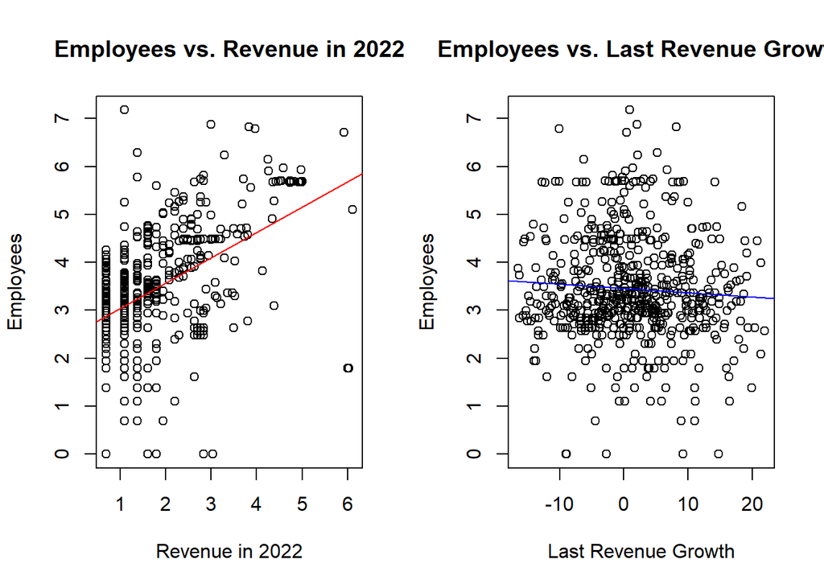

```r
# Create a layout with two plots side by side
par(mfrow = c(1, 2))

# Scatter plot for Revenue in 2022 vs. Employees with trendline
plot(Final_df_log$Revenue.in.2022_log, Final_df_log$Employees_log,
     xlab = "Revenue in 2022", ylab = "Employees",
     main = "Employees vs. Revenue in 2022")

# Fit a linear regression line and add it to the plot
fit <- lm(Employees_log ~ Revenue.in.2022_log, data = Final_df_log)
abline(fit, col = "red")

# Scatter plot for Employees vs. Last Revenue Growth with trendline
plot(Final_df_log$Last.Revenue.Growth, Final_df_log$Employees_log,
     xlab = "Last Revenue Growth", ylab = "Employees",
     main = "Employees vs. Last Revenue Growth")

# Fit a linear regression line and add it to the plot
fit_last_revenue <- lm(Employees_log ~ Last.Revenue.Growth, data = Final_df_log)
abline(fit_last_revenue, col = "blue")
```

Now let’s confirm the correlation values with correlation matrix

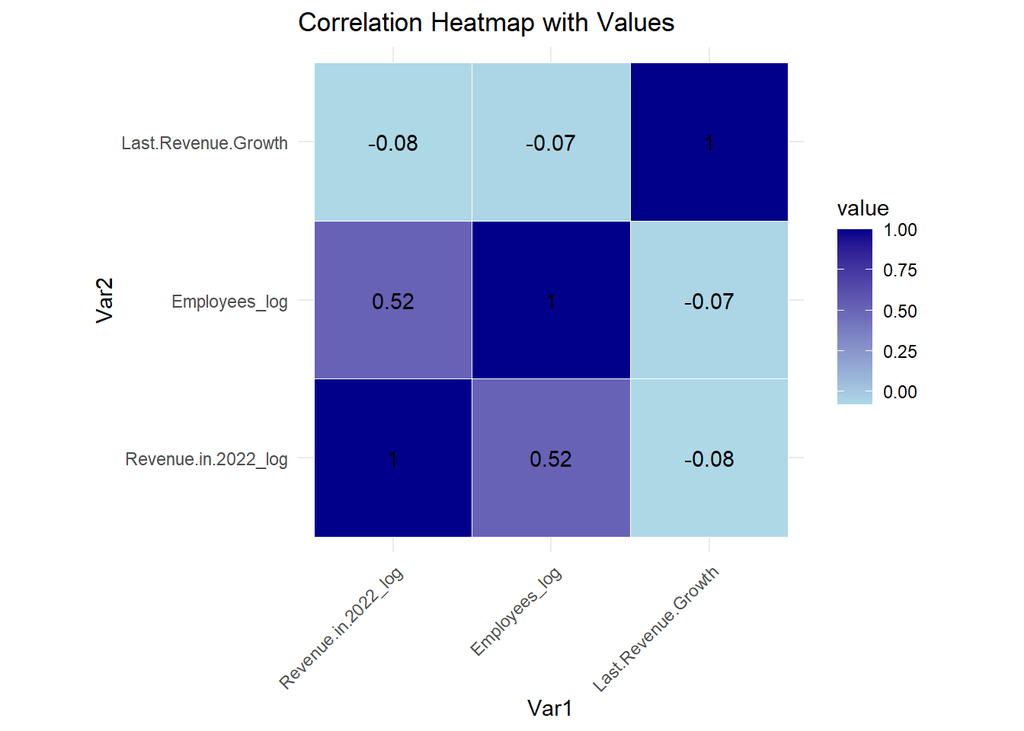

```r
correlation_matrix <- cor(Final_df_log[, c("Revenue.in.2022_log", "Employees_log", "Last.Revenue.Growth")])

# Visualize correlation matrix as a heatmap with values inside

# Convert correlation matrix to long format for plotting
correlation_melted <- melt(correlation_matrix)

# Plot heatmap of the correlation matrix with values inside
ggplot(correlation_melted, aes(Var1, Var2, fill = value, label = round(value, 2))) +
  geom_tile(color = "white") +
  geom_text(color = "black") +
  scale_fill_gradient(low = "lightblue", high = "darkblue") +
  labs(title = "Correlation Heatmap with Values") +
  theme_minimal() +
  theme(axis.text.x = element_text(angle = 45, hjust = 1)) +
  coord_fixed()
```

From here, we can confirm that there are high correlation between `Revenue.in.2022_log` vs. `Employees_log` while the `Last.Revenue.Growth` vs. `Employees_log` has low correlation.

Let’s try to correlate Categorical Variables next.

#### Categorical vs. Numerical Correlation

Correlation analysis for Categorical vs. Numerical is not straight forward as Numerical vs. Numerical. We will need to first breakdown the categories and find correlation of the breakdowns to further understand how Revenues are contributing to different parts of categories.

Let’s start with `Revenue.in.2022_log` as the dependent variable and explore the correlations between `Industry.Category` and `Location.Category`.

```r
# Unique industry categories
unique_categories <- unique(Final_df_log$Industry.Category)

# Create an empty list to store correlations for each category
correlation_list <- list()

#loop
for (category in unique_categories) {
  # Subset data for each category
  subset_data <- subset(Final_df_log, Industry.Category == category)

  # Calculate correlation between 'Revenue.in.2022_log' and other variables in the subset
  correlation <- cor.test(subset_data$Revenue.in.2022_log, subset_data$Employees_log)

  # Store correlation information in the list
  correlation_list[[category]] <- correlation
}

# Convert the correlation estimates and categories to a data frame
correlation_df <- data.frame(Category = unique_categories,
                             Correlation = sapply(correlation_list, function(x) x$estimate))

# Sort the data frame by Correlation from highest to lowest
correlation_df <- correlation_df[order(-correlation_df$Correlation), ]

# Print correlations from highest to lowest
for (i in 1:nrow(correlation_df)) {
  cat("Correlation for", correlation_df$Category[i], ":", correlation_df$Correlation[i], "\n")
}
```

```
## Correlation for Texiles : 0.9720721
## Correlation for Professional : 0.7741121
## Correlation for Other : 0.7206766
## Correlation for Construction : 0.6734928
## Correlation for Finance & Insurance : 0.6247985
## Correlation for F&B : 0.5824068
## Correlation for IT & Computer Services : 0.5681233
## Correlation for E-commerce : 0.546721
## Correlation for Retail Trade : 0.5183457
## Correlation for Telecommunications : 0.5016474
## Correlation for Administration : 0.371465
## Correlation for Media : 0.1360945
## Correlation for Transportation & Storage : -0.09883522
## Correlation for Electrical components : -0.9999847
```

```r
# Unique location categories
unique_locations <- unique(Final_df_log$Location.Category)

# Create an empty list to store correlations for each location category
correlation_list_location <- list()

# Loop through each unique location category
for (location in unique_locations) {
  # Subset data for each location category
  subset_data <- subset(Final_df_log, Location.Category == location)

  # Calculate correlation between 'Revenue.in.2022_log' and 'Employees_log' in the subset
  correlation <- cor.test(subset_data$Revenue.in.2022_log, subset_data$Employees_log)

  # Store correlation information in the list
  correlation_list_location[[location]] <- correlation
}

# Convert the correlation estimates and categories to a data frame for locations
correlation_df_location <- data.frame(Location = unique_locations,
                                      Correlation = sapply(correlation_list_location, function(x) x$estimate))

# Sort the data frame by Correlation from highest to lowest for locations
correlation_df_location <- correlation_df_location[order(-correlation_df_location$Correlation), ]

# Print correlations from highest to lowest for locations
for (i in 1:nrow(correlation_df_location)) {
  cat("Correlation for", correlation_df_location$Location[i], ":", correlation_df_location$Correlation[i], "\n")
}
```

```
## Correlation for Middle East : 0.7177035
## Correlation for North & South America : 0.7168009
## Correlation for Australia & New Zealand : 0.5966943
## Correlation for Asia-Pacific : 0.5756662
## Correlation for Europe : 0.5609685
## Correlation for Africa : 0.5587881
```

The best way to visualize this data is to use the bar chart since we have a lot of industry breakdowns

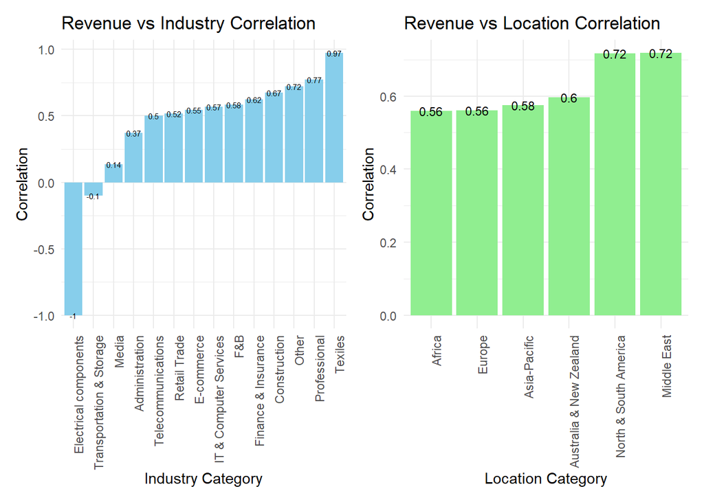

```r
library(ggplot2)
library(patchwork)
# Bar chart for correlation_df (Industry.Category)
plot_correlation_df <- ggplot(correlation_df, aes(x = reorder(Category, Correlation), y = Correlation)) +
  geom_bar(stat = "identity", fill = "skyblue") +
  geom_text(aes(label = round(Correlation, 2)), size = 2, color = "black") +
  labs(title = "Revenue vs Industry Correlation",
       x = "Industry Category", y = "Correlation") +
  theme_minimal() +
  theme(axis.text.x = element_text(angle = 90, hjust = 1))

# Bar chart for correlation_df_location (Location.Category)
plot_correlation_df_location <- ggplot(correlation_df_location, aes(x = reorder(Location, Correlation), y = Correlation)) +
  geom_bar(stat = "identity", fill = "lightgreen") +
  geom_text(aes(label = round(Correlation, 2)),  size = 3, color = "black") +
  labs(title = "Revenue vs Location Correlation",
       x = "Location Category", y = "Correlation") +
  theme_minimal() +
  theme(axis.text.x = element_text(angle = 90, hjust = 1))

# Arrange plots side by side on the same row
plot_correlation_df + plot_correlation_df_location +
  plot_layout(ncol = 2)
```

From here, we can see that most have positive correlations with the `Revenue.in.2022_log`.

Now let’s analyze with `Last.Revenue.Growth` as the dependent variable and explore the correlations between Industry and Locations.

```r
# Unique industry categories
unique_categories <- unique(Final_df_log$Industry.Category)

# Create an empty list to store correlations for each category
correlation_list_growth <- list()

# Loop through each unique category
for (category in unique_categories) {
  # Subset data for each category
  subset_data <- subset(Final_df_log, Industry.Category == category)

  # Calculate correlation between 'Last.Revenue.Growth' and 'Employees_log' in the subset
  correlation <- cor.test(subset_data$Last.Revenue.Growth, subset_data$Employees_log)

  # Store correlation information in the list
  correlation_list_growth[[category]] <- correlation
}

# Convert the correlation estimates and categories to a data frame for Last.Revenue.Growth
correlation_df_growth <- data.frame(Category = unique_categories,
                                    Correlation = sapply(correlation_list_growth, function(x) x$estimate))

# Sort the data frame by Correlation from highest to lowest for Last.Revenue.Growth
correlation_df_growth <- correlation_df_growth[order(-correlation_df_growth$Correlation), ]

# Print correlations from highest to lowest for Last.Revenue.Growth
for (i in 1:nrow(correlation_df_growth)) {
  cat("Correlation for", correlation_df_growth$Category[i], ":", correlation_df_growth$Correlation[i], "\n")
}
```

```
## Correlation for Electrical components : 0.8818947
## Correlation for Telecommunications : 0.2229753
## Correlation for Construction : 0.1277163
## Correlation for Transportation & Storage : 0.0847529
## Correlation for Administration : 0.07614184
## Correlation for Professional : 0.06467406
## Correlation for IT & Computer Services : -0.00192065
## Correlation for Retail Trade : -0.01463785
## Correlation for Other : -0.1103358
## Correlation for E-commerce : -0.1374407
## Correlation for Texiles : -0.2457637
## Correlation for Media : -0.3179541
## Correlation for F&B : -0.6200289
## Correlation for Finance & Insurance : -0.6678347
```

```r
# Unique location categories
unique_locations <- unique(Final_df_log$Location.Category)

# Create an empty list to store correlations for each location category
correlation_list_location_growth <- list()

# Loop through each unique location category
for (location in unique_locations) {
  # Subset data for each location category
  subset_data <- subset(Final_df_log, Location.Category == location)

  # Calculate correlation between 'Last.Revenue.Growth' and 'Employees_log' in the subset
  correlation <- cor.test(subset_data$Last.Revenue.Growth, subset_data$Employees_log)

  # Store correlation information in the list
  correlation_list_location_growth[[location]] <- correlation
}

# Convert the correlation estimates and categories to a data frame for locations
correlation_df_location_growth <- data.frame(Location = unique_locations,
                                             Correlation = sapply(correlation_list_location_growth, function(x) x$estimate))

# Sort the data frame by Correlation from highest to lowest for locations
correlation_df_location_growth <- correlation_df_location_growth[order(-correlation_df_location_growth$Correlation), ]

# Print correlations from highest to lowest for locations
for (i in 1:nrow(correlation_df_location_growth)) {
  cat("Correlation for", correlation_df_location_growth$Location[i], ":", correlation_df_location_growth$Correlation[i], "\n")
}
```

```
## Correlation for Africa : 0.374507
## Correlation for Middle East : 0.1808134
## Correlation for Asia-Pacific : 0.04474346
## Correlation for Europe : -0.164285
## Correlation for Australia & New Zealand : -0.1943485
## Correlation for North & South America : -0.3390054
```

Similarly let’s visualize these data into bar charts.

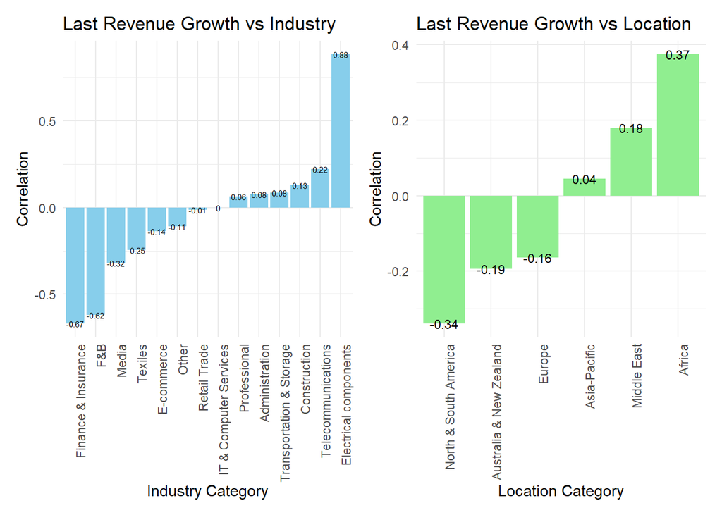

```r
# Bar chart for correlation_df_growth (Industry.Category)
plot_correlation_df_growth <- ggplot(correlation_df_growth, aes(x = reorder(Category, Correlation), y = Correlation)) +
  geom_bar(stat = "identity", fill = "skyblue") +
  geom_text(aes(label = round(Correlation, 2)), size = 2, color = "black") +
  labs(title = "Last Revenue Growth vs Industry",
       x = "Industry Category", y = "Correlation") +
  theme_minimal() +
  theme(axis.text.x = element_text(angle = 90, hjust = 1))

# Bar chart for correlation_df_location_growth (Location.Category)
plot_correlation_df_location_growth <- ggplot(correlation_df_location_growth, aes(x = reorder(Location, Correlation), y = Correlation)) +
  geom_bar(stat = "identity", fill = "lightgreen") +
  geom_text(aes(label = round(Correlation, 2)),  size = 3, color = "black") +
  labs(title = "Last Revenue Growth vs Location",
       x = "Location Category", y = "Correlation") +
  theme_minimal() +
  theme(axis.text.x = element_text(angle = 90, hjust = 1))

# Arrange plots side by side on the same row
plot_correlation_df_growth + plot_correlation_df_location_growth +
  plot_layout(ncol = 2)
```

From here, we can see that there are quite a handful of correlation outcomes that has less than 0 correlation.

### Conclusion

In this section, we mainly focused on the correlations between dependent variables and independent variables and here are few key takeaways that we can consider to structure our models:

- `Revenue.in.2022_log` is suggested to be the main dependent variable as it has high correlation to a lot of independent variables comparatively with `Last.Revenue.Growth`. However, few techniques need to be applied to cater potential skewness challenges.
- Regression modeling can be the main model for our project, and using Employees as the independent variable can produce a much more straightforward result.
- We can also test out other models like Classification, Random Forest etc to predict Revenue Growth and test out other variables.

## Regression Model

### Split Data

After completing the process of cleaning the dataset, the next step involves developing a predictive model using the refined data. Before we carry out training process, we need to initiate the split the data into training sets and test sets.

```r
#Load necessary packages
library(caret)
library(glmnet)
# Split the data into training and testing sets
set.seed(123)
# Create a data partition for training and testing
train_index <- createDataPartition(Final_df_log$Revenue.in.2022_log, p = 0.8, list = FALSE)

# Extract the training and testing data
train_data <- Final_df_log[train_index, ]
test_data <- Final_df_log[-train_index, ]
```

### Data Modeling

This modeling phase is essential for gaining insights into the relationships between variables and understanding how they contribute to the target outcome. By leveraging statistical techniques, such as linear regression modeling, we can create a model that captures the underlying patterns in the data

```r
# Create a simple linear regression model with "Employees_log" as the only independent variable
model <- lm(Revenue.in.2022_log ~ Employees_log, data = train_data)

# Summarize the linear regression model
model_summary <- summary(model)

# Print the model summary
print(model_summary)
```

```
##
## Call:
## lm(formula = Revenue.in.2022_log ~ Employees_log, data = train_data)
##
## Residuals:
##     Min      1Q  Median      3Q     Max
## -2.6931 -0.6510 -0.2719  0.4414  5.1399
##
## Coefficients:
##               Estimate Std. Error t value Pr(>|t|)
## (Intercept)   -0.06769    0.14392   -0.47    0.638
## Employees_log  0.53763    0.03956   13.59   <2e-16 ***
## ---
## Signif. codes:  0 '***' 0.001 '**' 0.01 '*' 0.05 '.' 0.1 ' ' 1
##
## Residual standard error: 0.9576 on 477 degrees of freedom
## Multiple R-squared:  0.2791, Adjusted R-squared:  0.2776
## F-statistic: 184.7 on 1 and 477 DF,  p-value: < 2.2e-16
```

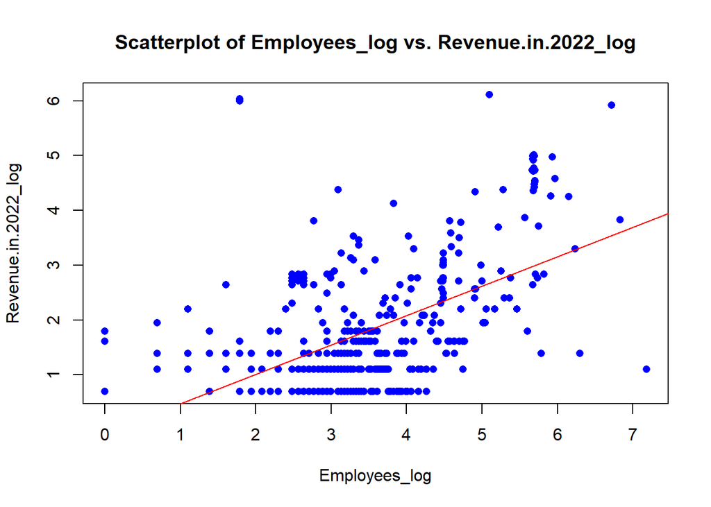

```r
# Visualize the relationship between Employees_log and Revenue.in.2022_log
plot(train_data$Employees_log, train_data$Revenue.in.2022_log, main = "Scatterplot of Employees_log vs. Revenue.in.2022_log",
     xlab = "Employees_log", ylab = "Revenue.in.2022_log", col = "blue", pch = 16)

# Add the regression line to the scatterplot
abline(model, col = "red")
```

#### Test Result

The testing phase enables us to understand how well the model generalizes to new, unseen data and provides insights into its predictive capabilities.

```r
# Predictions on the test set
predictions <- predict(model, newdata = test_data)

# Model Evaluation on the test set
# Calculate Root Mean Squared Error (RMSE) and Mean Absolute Error (MAE)
rmse <- sqrt(mean((predictions - test_data$Revenue.in.2022_log)^2))
mae <- mean(abs(predictions - test_data$Revenue.in.2022_log))

# Print evaluation metrics
cat("Root Mean Squared Error (RMSE):", rmse, "\n")
```

```
## Root Mean Squared Error (RMSE): 0.7910697
```

```r
cat("Mean Absolute Error (MAE):", mae, "\n")
```

```
## Mean Absolute Error (MAE): 0.6073597
```

```r
# Additional Model Evaluation Metrics
# Calculate R-squared
rsquared <- summary(model)$r.squared
cat("R-squared:", rsquared, "\n")
```

```
## R-squared: 0.2790829
```

```r
# Calculate Adjusted R-squared
adj_rsquared <- summary(model)$adj.r.squared
cat("Adjusted R-squared:", adj_rsquared, "\n")
```

```
## Adjusted R-squared: 0.2775716
```

#### Analyze Results

This process guides decisions related to model deployment, further refinement, and continuous improvement.

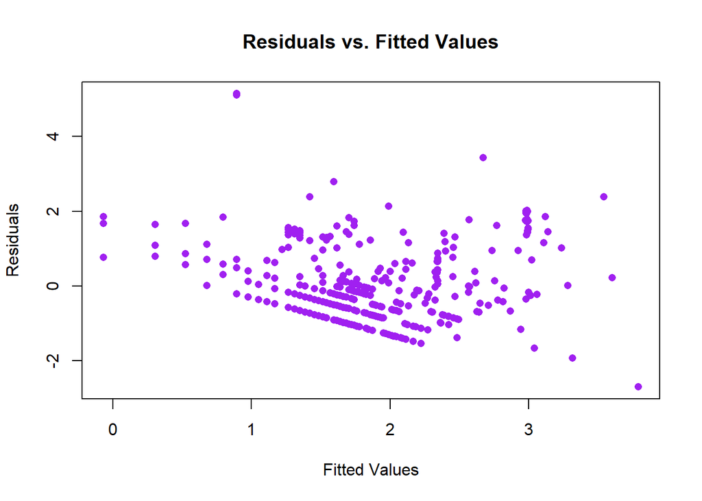

```r
# Residual Analysis: Plot residuals vs. fitted values
residuals <- residuals(model)
fitted_values <- fitted(model)
plot(fitted_values, residuals, main = "Residuals vs. Fitted Values",
     xlab = "Fitted Values", ylab = "Residuals", col = "purple", pch = 16)
```

```r
# Perform Shapiro-Wilk test for normality of residuals
shapiro_test <- shapiro.test(residuals)
cat("Shapiro-Wilk test p-value:", shapiro_test$p.value, "\n")
```

```
## Shapiro-Wilk test p-value: 5.673278e-17
```

## Classification Model

Tittle: *To predict the likelihood of a company’s success in achieving positive revenue growth in 2023*

### Data Preparation

Ensure the dataset is clean and does not have missing values.

```r
head(Final_df_log, 5)
```

```
##   Revenue.in.2022_log Employees_log Last.Revenue.Growth     Industry.Category
## 1            6.109248      5.099866                0.05                   F&B
## 2            6.035481      1.791759               -2.72 Electrical components
## 3            6.001415      1.791759                0.03 Electrical components
## 4            5.924256      6.715383                0.41          Retail Trade
## 6            5.010635      5.686975              -10.61                 Other
##       Location.Category
## 1 North & South America
## 2                Europe
## 3                Europe
## 4          Asia-Pacific
## 6                Europe
```

```r
summary(Final_df_log)
```

```
##  Revenue.in.2022_log Employees_log   Last.Revenue.Growth Industry.Category
##  Min.   :0.6931      Min.   :0.000   Min.   :-16.440     Length:595
##  1st Qu.:1.0986      1st Qu.:2.833   1st Qu.: -4.405     Class :character
##  Median :1.3863      Median :3.258   Median :  0.780     Mode  :character
##  Mean   :1.7724      Mean   :3.448   Mean   :  1.181
##  3rd Qu.:2.3979      3rd Qu.:4.052   3rd Qu.:  6.545
##  Max.   :6.1092      Max.   :7.179   Max.   : 21.880
##  Location.Category
##  Length:595
##  Class :character
##  Mode  :character
##
##
##
```

```r
# check for duplicate rows
duplicaterow <- sum(duplicated(df))
cat("duplicate data :", duplicaterow)
```

```
## duplicate data : 0
```

```r
#check for missing data
colSums(is.na(Final_df_log))
```

```
## Revenue.in.2022_log       Employees_log Last.Revenue.Growth   Industry.Category
##                   0                   0                   0                   0
##   Location.Category
##                   0
```

3. Encode categorical variables (Last.Revenue.Growth)

This is to set the dependent variable as the binary outcome (positive revenue growth or not), and the independent variables as the numbers of employee.

```r
# Encode categorical variable
Final_df_log$Encoded.Last.Revenue.Growth <- ifelse(Final_df_log$Last.Revenue.Growth > 0, 1, 0)

# Print the updated dataset
head(Final_df_log,5)
```

```
##   Revenue.in.2022_log Employees_log Last.Revenue.Growth     Industry.Category
## 1            6.109248      5.099866                0.05                   F&B
## 2            6.035481      1.791759               -2.72 Electrical components
## 3            6.001415      1.791759                0.03 Electrical components
## 4            5.924256      6.715383                0.41          Retail Trade
## 6            5.010635      5.686975              -10.61                 Other
##       Location.Category Encoded.Last.Revenue.Growth
## 1 North & South America                           1
## 2                Europe                           0
## 3                Europe                           1
## 4          Asia-Pacific                           1
## 6                Europe                           0
```

### Splitting Data

Split the dataset into training and testing sets.

```r
#Count numbers of rows
number_rows <- nrow(Final_df_log)
# Print the number of rows
print(paste("Number of rows:", number_rows))
```

```
## [1] "Number of rows: 595"
```

```r
# Set the seed for reproducibility
set.seed(123)
# Specify the split ratio
split <- 0.80
# Sample for the training set
train_data <- sample(seq_len(nrow(Final_df_log)), split * nrow(Final_df_log))
# Create the training set
training_set <- Final_df_log[train_data, ]
# Create the testing set by excluding the training set indices
testing_set <- Final_df_log[-train_data, ]
# Print the training and testing sets
print(paste("Training set size:", nrow(training_set)))
```

```
## [1] "Training set size: 476"
```

```r
print(paste("Testing set size:", nrow(testing_set)))
```

```
## [1] "Testing set size: 119"
```

## Logistic Regression Model

```r
# Perform logistic regression
logistic_model <- glm(Encoded.Last.Revenue.Growth ~ Employees_log, data = training_set, family = "binomial")
# Print the summary of the logistic regression model
summary(logistic_model)
```

```
##
## Call:
## glm(formula = Encoded.Last.Revenue.Growth ~ Employees_log, family = "binomial",
##     data = training_set)
##
## Coefficients:
##               Estimate Std. Error z value Pr(>|z|)
## (Intercept)    0.62140    0.30536   2.035   0.0419 *
## Employees_log -0.11649    0.08416  -1.384   0.1663
## ---
## Signif. codes:  0 '***' 0.001 '**' 0.01 '*' 0.05 '.' 0.1 ' ' 1
##
## (Dispersion parameter for binomial family taken to be 1)
##
##     Null deviance: 654.18  on 475  degrees of freedom
## Residual deviance: 652.26  on 474  degrees of freedom
## AIC: 656.26
##
## Number of Fisher Scoring iterations: 4
```

### Model Evaluation:

Evaluate the model’s performance on the testing dataset using appropriate metrics such as accuracy, precision, recall, and F1 score.

```r
# Predict on the testing set
predicted_probs <- predict(logistic_model, newdata = testing_set, type = "response")
predicted_Revenue.growth <- ifelse(predicted_probs > 0.5, 1, 0)
# Evaluate the model
conf_matrix <- table(predicted_Revenue.growth, testing_set$Encoded.Last.Revenue.Growth)
# Create a new confusion matrix with updated labels
new_conf_matrix <- conf_matrix
# Rename rows (predicted labels)
rownames(new_conf_matrix) <- c("Actual 0", "Actual 1")
# Rename columns (true labels)
colnames(new_conf_matrix) <- c("Predicted 0", "Predicted 1")
# Print the updated confusion matrix
print(new_conf_matrix)
```

```
##
## predicted_Revenue.growth Predicted 0 Predicted 1
##                 Actual 0           2           5
##                 Actual 1          54          58
```

### Interpretation

Results:

1.(True Positives) The model correctly predicted positive revenue growth in 58 instances .

4.(True Negative) The model correctly predicted no positive revenue growth in 2 instance .

```r
# Confusion matrix values
TP <- 58
FP <- 5
FN <- 54
TN <- 2

# Calculate Accuracy
accuracy <- (TP + TN) / (TP + FP + FN + TN)
# Calculate Precision
precision <- TP / (TP + FP)
# Calculate Recall (Sensitivity or True Positive Rate)
recall <- TP / (TP + FN)
# Calculate Specificity (True Negative Rate)
specificity <- TN / (TN + FP)
# Calculate F1 Score
f1_score <- 2 * (precision * recall) / (precision + recall)

# Print the results
print(paste("Accuracy:", round(accuracy, 4)))
```

```
## [1] "Accuracy: 0.5042"
```

```r
print(paste("Precision:", round(precision, 4)))
```

```
## [1] "Precision: 0.9206"
```

```r
print(paste("Recall:", round(recall, 4)))
```

```
## [1] "Recall: 0.5179"
```

```r
print(paste("Specificity:", round(specificity, 4)))
```

```
## [1] "Specificity: 0.2857"
```

```r
print(paste("F1 Score:", round(f1_score, 4)))
```

```
## [1] "F1 Score: 0.6629"
```

## Random Forest

Factorize for ‘Encoded.Last.Revenue.Growth’

```r
Final_df_log$Factor.Last.Revenue.Growth <- as.factor(gsub(",", "", Final_df_log$Encoded.Last.Revenue.Growth))
```

Split data

```r
# Set the seed for reproducibility
set.seed(123)
# Specify the split ratio
split <- 0.80
# Sample for the training set
train_data1 <- sample(seq_len(nrow(Final_df_log)), split * nrow(Final_df_log))
# Create the training set
training_set1 <- Final_df_log[train_data, ]
# Create the testing set by excluding the training set indices
testing_set1 <- Final_df_log[-train_data, ]
# Print the training and testing sets
print(paste("Training set size:", nrow(training_set1)))
```

```
## [1] "Training set size: 476"
```

```r
print(paste("Testing set size:", nrow(testing_set1)))
```

```
## [1] "Testing set size: 119"
```

```r
# Install the 'randomForest' package
install.packages("randomForest")
# Load the 'randomForest' package
library(randomForest)
# Train the Random Forest model
rf_model <- randomForest::randomForest(Factor.Last.Revenue.Growth ~  Employees_log, data = training_set1)
# Make predictions on the testing set
predicted_Revenue.growth <- predict(rf_model, newdata = testing_set1, type = "response")
```

### Model Evaluation

```r
# Evaluate the model (e.g., confusion matrix, accuracy, etc.)
conf_matrix <- table(predicted_Revenue.growth, testing_set1$Factor.Last.Revenue.Growth)
# Create a new confusion matrix with updated labels
rf_conf_matrix <- conf_matrix
# Rename rows (predicted labels)
rownames(rf_conf_matrix) <- c("Actual 0", "Actual 1")
# Rename columns (true labels)
colnames(rf_conf_matrix) <- c("Predicted 0", "Predicted 1")
# Print the updated confusion matrix
print(rf_conf_matrix)
```

```
##
## predicted_Revenue.growth Predicted 0 Predicted 1
##                 Actual 0          26          26
##                 Actual 1          30          37
```

### Interpretation

Results:

1.(True Positives) The model correctly predicted positive revenue growth in 37 instances .

4.(True Negative) The model correctly predicted no positive revenue growth in 26 instance .

```r
# Confusion matrix values
TP <- 37
FP <- 26
FN <- 30
TN <- 26

# Calculate Accuracy
accuracy <- (TP + TN) / (TP + FP + FN + TN)
# Calculate Precision
precision <- TP / (TP + FP)
# Calculate Recall (Sensitivity or True Positive Rate)
recall <- TP / (TP + FN)
# Calculate Specificity (True Negative Rate)
specificity <- TN / (TN + FP)
# Calculate F1 Score
f1_score <- 2 * (precision * recall) / (precision + recall)

# Print the results
print(paste("Accuracy:", round(accuracy, 4)))
```

```
## [1] "Accuracy: 0.5294"
```

```r
print(paste("Precision:", round(precision, 4)))
```

```
## [1] "Precision: 0.5873"
```

```r
print(paste("Recall:", round(recall, 4)))
```

```
## [1] "Recall: 0.5522"
```

```r
print(paste("Specificity:", round(specificity, 4)))
```

```
## [1] "Specificity: 0.5"
```

```r
print(paste("F1 Score:", round(f1_score, 4)))
```

```
## [1] "F1 Score: 0.5692"
```

## Naive Bayes model

```r
# Load the necessary library
library(e1071)
# Train a Naive Bayes model
naive_bayes_model <- naiveBayes(Encoded.Last.Revenue.Growth ~ Employees_log, data = training_set)
# Make predictions on the testing set
predicted_probs <- predict(naive_bayes_model, testing_set, type = "raw")
# Convert predicted probabilities to labels
predicted_Revenue.growth <- predict(naive_bayes_model, testing_set, type = "class")
```

### Model Evaluation

```r
# Create a confusion matrix
conf_matrix <- table(predicted_Revenue.growth,testing_set$Encoded.Last.Revenue.Growth)
# Create a new confusion matrix with updated labels
nb_conf_matrix <- conf_matrix
# Rename rows (predicted labels)
rownames(nb_conf_matrix) <- c("Actual 0", "Actual 1")
# Rename columns (true labels)
colnames(nb_conf_matrix) <- c("Predicted 0", "Predicted 1")
# Print the updated confusion matrix
print(nb_conf_matrix)
```

```
##
## predicted_Revenue.growth Predicted 0 Predicted 1
##                 Actual 0           0           0
##                 Actual 1          56          63
```

Results:

4.(True Negative) The model correctly predicted no positive revenue growth in 0 instance .

```r
# Confusion matrix values
TP <- 56
FP <- 0
FN <- 63
TN <- 0

# Calculate Accuracy
accuracy <- (TP + TN) / (TP + FP + FN + TN)
# Calculate Precision
precision <- TP / (TP + FP)
# Calculate Recall (Sensitivity or True Positive Rate)
recall <- TP / (TP + FN)
# Calculate Specificity (True Negative Rate)
specificity <- TN / (TN + FP)
# Calculate F1 Score
f1_score <- 2 * (precision * recall) / (precision + recall)

# Print the results
print(paste("Accuracy:", round(accuracy, 4)))
```

```
## [1] "Accuracy: 0.4706"
```

```r
print(paste("Precision:", round(precision, 4)))
```

```
## [1] "Precision: 1"
```

```r
print(paste("Recall:", round(recall, 4)))
```

```
## [1] "Recall: 0.4706"
```

```r
print(paste("Specificity:", round(specificity, 4)))
```

```
## [1] "Specificity: NaN"
```

```r
print(paste("F1 Score:", round(f1_score, 4)))
```

```
## [1] "F1 Score: 0.64"
```

## Conclusion

In conclusion, the 2 objectives are answered:

1. To Explore the Relationship Between a Company’s Employee Count and Revenue in 2022

Company’s Employee Count have positive relationship to its revenue in 2022 with R2 score = 0.2790829 and RMSE = 0.7910697.

2. To Predict the Likelihood of Positive Revenue Growth in 2023

Even though both regression and classification model doesn’t producing satisfactory results but it’s important to conduct a thorough evaluation and analysis to understand the limitations and potential areas for improvement.

These are what we do under this situation:

1. Re-evaluate Data Quality: Data cleaning and pre-processing are done correctly, Missing values, outlier are already been processed.
2. Feature Engineering: We had also select the correct feature based on the corelation matrix.
3. Model Selection: The regression model we use linear regression and for classification model we use 3 models. For regression, perhaps we could use another model just to compare the result with linear regression. For classification, 3 models all showing similar result hence we can eliminate factor which the model not performing well is because of wrong model selection.
4. Hyperparameter Tuning: With such non-satisfactory result, hyperparameter will not improve much on accuracy.
5. Cross-Validation: We didn’t use cross-validation technique is because the dataset is small hence we use the random splitting technique. However, this shall not be the factors as we have run the code several time and all showing similar result.
6. Model Complexity: Our dataset is a simple dataset and the model we use are also not a complex model. Hence this shall not be the factor.
7. Gather Domain Knowledge: This is not applicable for our case.
8. Acceptance of Constraints: Sometimes, due to data limitations or the nature of the problem, achieving high accuracy result might not be feasible.

In conclusion, the 2 objectives are answered even the model result are not producing satisfactory result. High predictive accuracy is not feasible mainly due to the data limitation and the nature of the problem. The only improvement we can work on will be try on more than one linear regression model.